# Group Lab 1 - Changes in the Geography of Chinese Production

Group 4 - Daniella, Emmi, Gabby, Macklan, Sean

January 25, 2019

## Part 1: Understanding Our Data

This dataset is derived from the [All China Data Center](https://chinadatacenter.net/Data/Services.aspx) which is formerly affiliated with the University of Michigan. The All China Data Center is run by the All China Marketing Research company, a private research firm.

While it seems odd that cities like Shanghai and Beijing are included in statistics with provinces, they are special cases in that they are technically [municipalities](https://en.wikipedia.org/wiki/Direct-administered_municipalities_of_China). They have a higher political status than other types of cities, and are considered to be on the same level as provinces. Because they are under direct control of the central government, they are included in this dataset. Other major cities of Tianjin and Chongqing are also classified as municipalities.

Additionally, Hong Kong and Macau are not included in this dataset becuase although they are “special administrative regions” (SAR) of the PRC, SAR’s are “highly autonomous and self-governing sub national subject of the People’s Republic of China that is directly under the Central People’s Government”. In this way, Hong Kong and Macau control their own economies, are only really tied to China in terms of foreign policy and military/defense and therefore produce economic statistics through their own governments. To view Macau’s economic data it can be accessed [here](https://www.gov.mo/en/about-macao-sar/statistics/). To view Hong Kong’s economic data it can be accessed [here](https://www.hkeconomy.gov.hk/en/situation/index.htm).

Sources:

- Economic History of China, 1949 to present
- [How Trustworty are Chinese Statistics?, JapanForward](https://japan-forward.com/how-trustworthy-are-chinese-statistics-china-inflates-gdp-figures-by-478-billion-in-2017/)
- Macau
- [China Quietly Releases 2017 Provincial GDP Figures, Forbes](https://www.forbes.com/sites/salvatorebabones/2018/02/12/china-quietly-releases-2017-provincial-gdp-figures/#799c69ed20dc)
- [The Problem of Chinese Statistics, CIA](https://www.cia.gov/library/center-for-the-study-of-intelligence/kent-csi/vol16no4/html/v17i1a07p_0001.htm)

## Part 2: Exploring and Visualizing the Data

Using the dataset from [All China Data Center](https://chinadatacenter.net/Data/Services.aspx), we were able to identify patterns, trends, and other interesting things within the enterprise and output data.

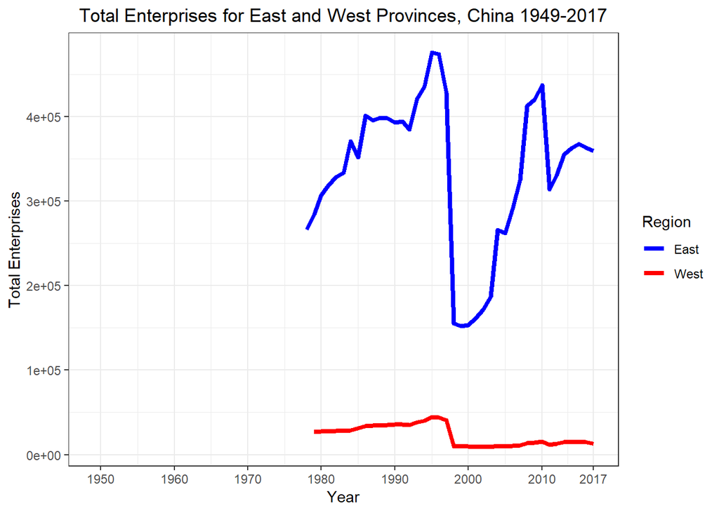

The division of Eastern and Western is delineated based on the [15-inch Isohyet](https://www.forbes.com/sites/johnmauldin/2016/02/25/5-maps-that-explain-chinas-strategy/#3c257f4165b7). The Eastern provinces are much more densely populated than the Western. Looking at this graph, there are no recorded enterprises until around 1980. The Western provinces see little change in their enterprises totals but does undergo a large drop around 1998/1999. While the Eastern Provinces experience much more variability, both regions experiences similar periods of “highs” around 1995 and 2010, and similiar periods of “lows” in 1998/1999 and 2011. _____________________________________________________________________________________________________________________

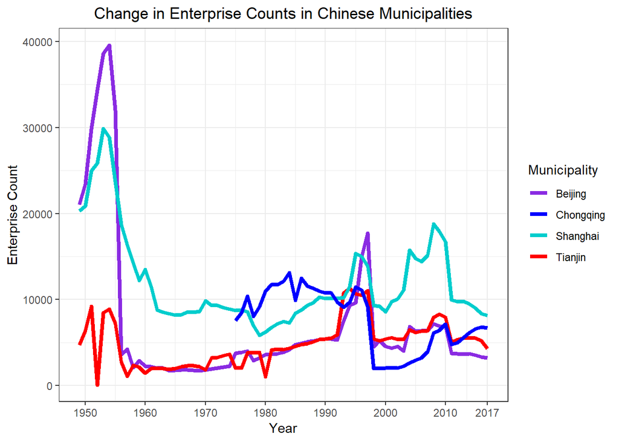

The graph is a plot of enterprise counts of the four non-province municipalities included in the data. A sharp decline in the mid-1950s is attributed to private farms being aggregated into larger organizations. On the plot, it appears as though the count decreased and enterprises had a mass closing, but it was the result of combining these individual entities. Influential economic reforms started in 1979, causing new growth. Patterns post-2000 are indicative of a growing GDP in the late 2000s followed by a decline in growth. Source: [China’s Economic Rise by Wayne Morrison](https://fas.org/sgp/crs/row/RL33534.pdf) _____________________________________________________________________________________________________________________

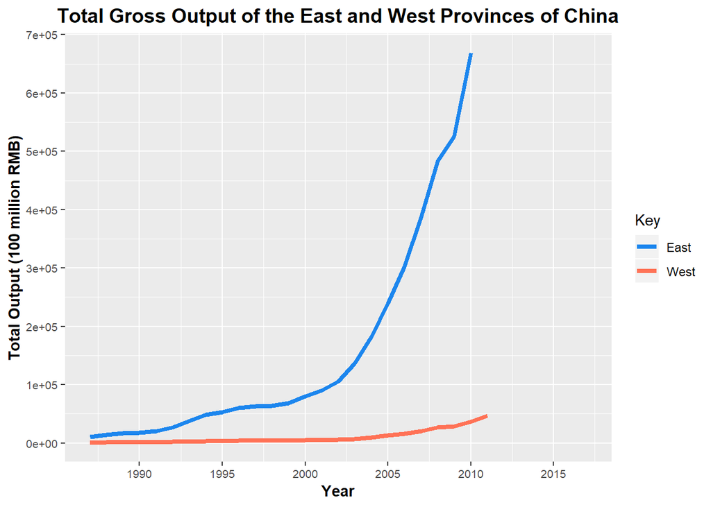

China is essentially broken up into two main regions: the East and West regions, which are divided by the [15-inch Isohyet](https://www.forbes.com/sites/johnmauldin/2016/02/25/5-maps-that-explain-chinas-strategy/#3c257f4165b7). This line represents the divide based on annual rainfall needed for an agricultural economy. The Western provinces receive less than 15-inches of rainfall a year, resulting in smaller economic outputs. On the contrary, the Eastern provinces and municipalities get the majority of the yearly rainfall, which contribute to higher economic outputs and greater population density. Thus, this graph aims to show the significant total outputs each region has over the course of a 30-year period. _____________________________________________________________________________________________________________________

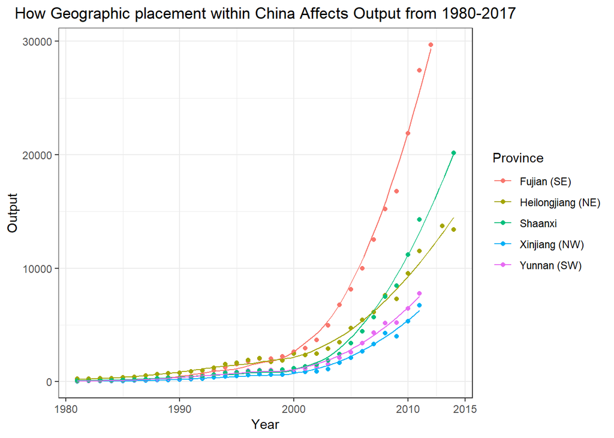

China has a very diverse economy, although it does not appear that way according to the media. China is commonly known for its manufacturing, but China still has a very large portion of its economy in agriculture. China’s size and diverse landscapes plays a large part into why it is still has a large agricultural industry. In order to understand how different every province is within China, we decided to look at the four “corners” of China, as well as a province right in the center of the country.

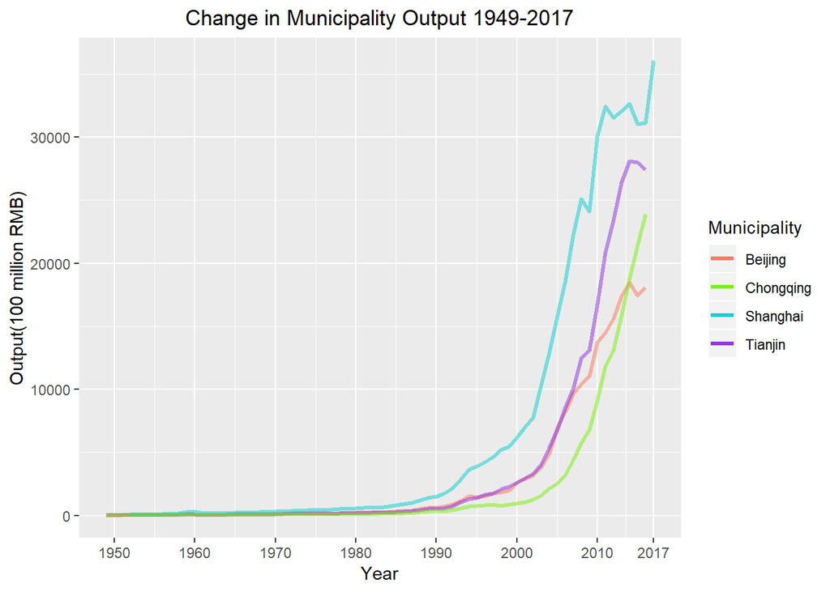

The graph “Change in Municpality Output 1949-2017” shows the increase in output from each municipality of China between 1949 and 2017. When comparing to the graph “of change in municipality enterprises”Change in Enterprise Counts for Municipalities" above, we can see a reverse trend between the amount of enterprises and output. Enterprises decrease from 1949 to 2017 while output increases. This is due to enterprises absorbing other enterprises to increase output, the creation of monopolies, or from a increase in activity from social, political, and economic variables. _____________________________________________________________________________________________________________________

## Part 3: Modifying the Data

Below are some interesting comparisons between providences from the North and South, and providences from the East and West. We used a function to automate output ratios between the providences.

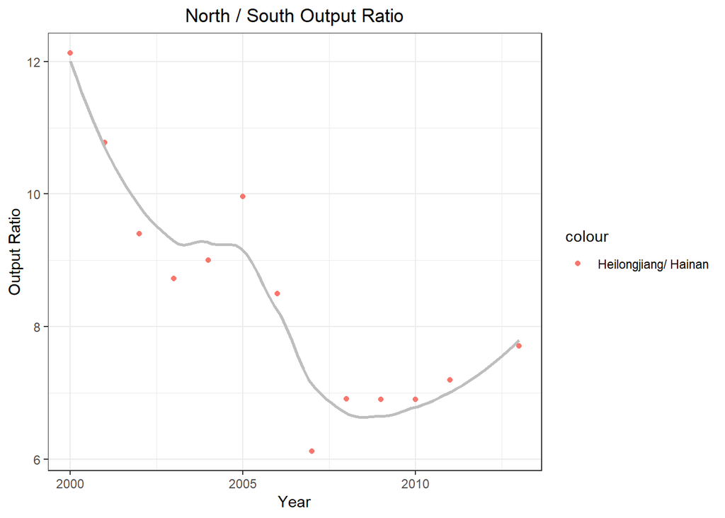

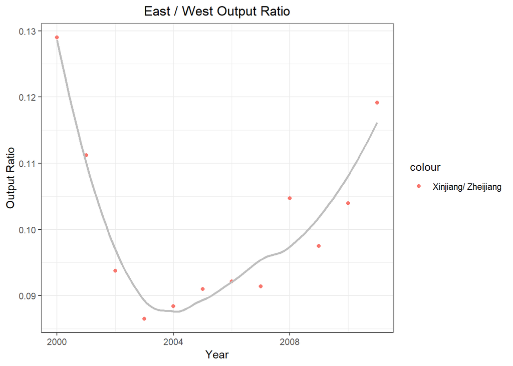

_____________________________________________________________________________________________________________________

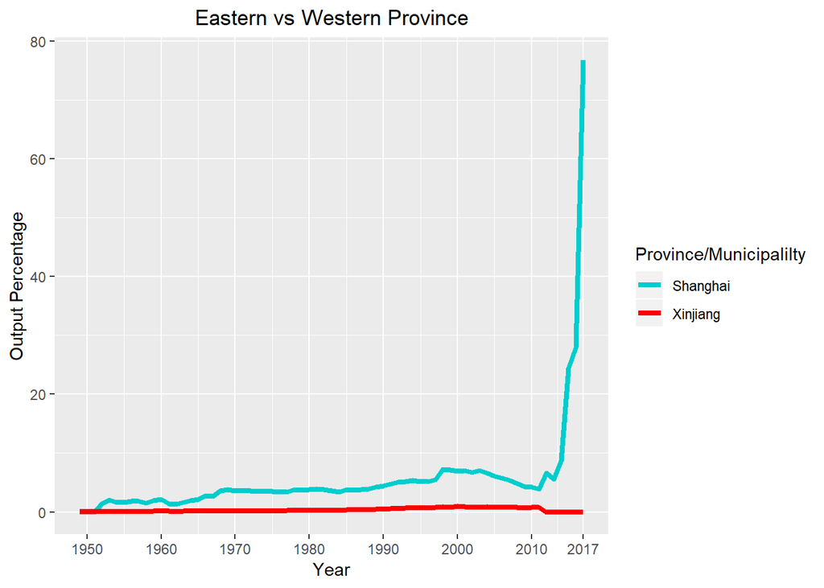

_____________________________________________________________________________________________________________________